```r
library(ISLR) # Cargar librería con los datos
library(ggplot2)
library(MLmetrics)
library(MASS)
library(class)
```

# Apartado 4.7

# Punto 10

## Introducción

En el siguiente estudio, se presentan resultados analíticos del set de datos Weekly del paquete ISLR, este set de datos contiene los datos del porcentaje de retorno del índice S&P 500 a lo largo de las semanas en 20 años, desde 1990 hasta 2010.

El set de datos contiene las variables año, el retorno porcentual de la semana, 5 variables del retorno porcentual de cada una de las semanas anteriores, una variable volumen (número promedio de acciones comerciadas diariamente, en billones), y finalmente la dirección, que indica si el retorno fue positivo o negativo dicha semana.

```r
head(Weekly)
```

```
##   Year   Lag1   Lag2   Lag3   Lag4   Lag5    Volume  Today Direction
## 1 1990  0.816  1.572 -3.936 -0.229 -3.484 0.1549760 -0.270      Down
## 2 1990 -0.270  0.816  1.572 -3.936 -0.229 0.1485740 -2.576      Down
## 3 1990 -2.576 -0.270  0.816  1.572 -3.936 0.1598375  3.514        Up
## 4 1990  3.514 -2.576 -0.270  0.816  1.572 0.1616300  0.712        Up
## 5 1990  0.712  3.514 -2.576 -0.270  0.816 0.1537280  1.178        Up
## 6 1990  1.178  0.712  3.514 -2.576 -0.270 0.1544440 -1.372      Down
```

## Literal a), Resumen de los datos

El resumen de los datos muestra un promedio de crecimiento porcentual positivo del día de $0.14\%$, lo que indica que a lo largo del tiempo el porcentaje de retorno del S&P es bastante variable y tiende a mantener un equilibrio entre incremento y disminución del mismo.

La variable ‘Direction’ muestra $605$ subidas contra $484$ caídas, lo que indica que a la larga el S&P incrementa su valor en el tiempo.

```r
summary(Weekly)
```

```
##       Year           Lag1               Lag2               Lag3
##  Min.   :1990   Min.   :-18.1950   Min.   :-18.1950   Min.   :-18.1950
##  1st Qu.:1995   1st Qu.: -1.1540   1st Qu.: -1.1540   1st Qu.: -1.1580
##  Median :2000   Median :  0.2410   Median :  0.2410   Median :  0.2410
##  Mean   :2000   Mean   :  0.1506   Mean   :  0.1511   Mean   :  0.1472
##  3rd Qu.:2005   3rd Qu.:  1.4050   3rd Qu.:  1.4090   3rd Qu.:  1.4090
##  Max.   :2010   Max.   : 12.0260   Max.   : 12.0260   Max.   : 12.0260
##       Lag4               Lag5              Volume            Today
##  Min.   :-18.1950   Min.   :-18.1950   Min.   :0.08747   Min.   :-18.1950
##  1st Qu.: -1.1580   1st Qu.: -1.1660   1st Qu.:0.33202   1st Qu.: -1.1540
##  Median :  0.2380   Median :  0.2340   Median :1.00268   Median :  0.2410
##  Mean   :  0.1458   Mean   :  0.1399   Mean   :1.57462   Mean   :  0.1499
##  3rd Qu.:  1.4090   3rd Qu.:  1.4050   3rd Qu.:2.05373   3rd Qu.:  1.4050
##  Max.   : 12.0260   Max.   : 12.0260   Max.   :9.32821   Max.   : 12.0260
##  Direction
##  Down:484
##  Up  :605
##
##
##
##
```

En el siguiente Diagrama de Caja se pueden identificar la varianza de los datos en cada año

Los años con una varianza menor se podrían relacionar con años con poca incertidumbre económica, mientras que los años con una varianza mayor podrían relacionarse con años en los que el S&P se comportó de una manera más volátil, un ejemplo de esto es el año 2008, donde ocurrió una crisis financiera y una [crisis bursátil mundial](https://es.wikipedia.org/wiki/Crisis_bursátil_mundial_de_octubre_de_2008)

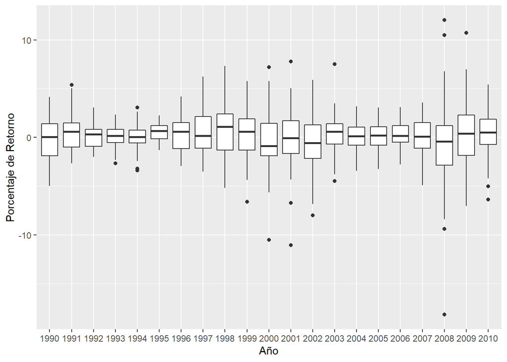

```r
Weekly$YFactor <- as.factor(Weekly$Year) # Año como factor para producir un Box Plot
ggplot(data= Weekly, mapping = aes(x = YFactor, y= Today)) +
  geom_boxplot() +
  xlab("Año") +
  ylab("Porcentaje de Retorno")
```

### Gráfica histórica de los puntos

La gráfica histórica de los puntos muestra el constante incremento y disminución del porcentaje de retorno, sobresalen los puntos alrededor del año 2008 debido a la crisis financiera ya mencionada.

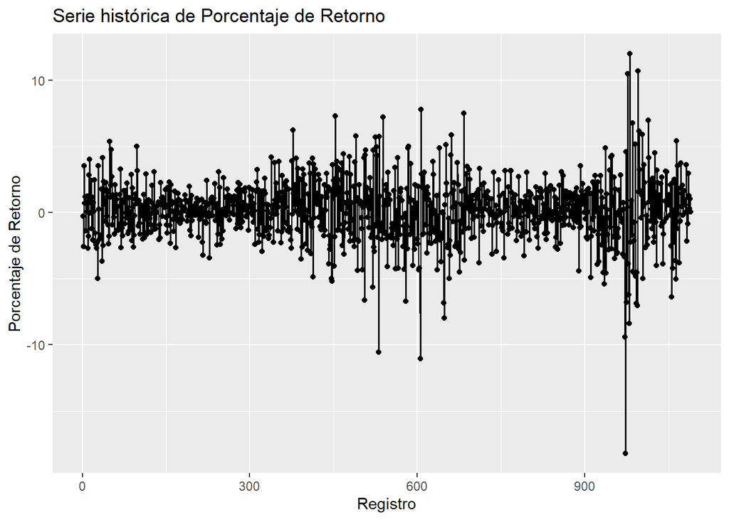

```r
ggplot(data= Weekly, mapping = aes(x = c(1:length(Year)), y= Today)) +
  geom_line() +
  geom_point() +
  xlab("Registro") +
  ylab("Porcentaje de Retorno") +
  labs(title="Serie histórica de Porcentaje de Retorno")
```

Se realiza una gráfica con menos puntos para poder visualizar de una mejor manera.

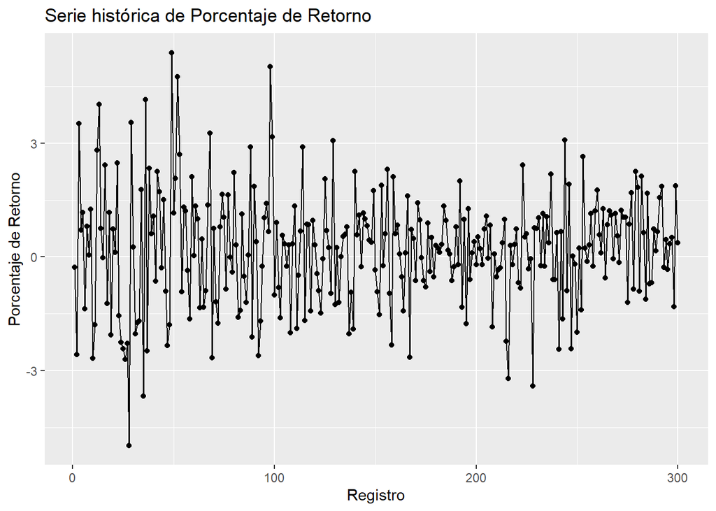

```r
ggplot(data= Weekly[1:300,], mapping = aes(x = c(1:length(Year)), y= Today)) +
  geom_line() +
  geom_point() +
  xlab("Registro") +
  ylab("Porcentaje de Retorno") +
  labs(title="Serie histórica de Porcentaje de Retorno")
```

## Literal b), Regresión logística

Se realiza una regresión logística con todos los datos, tienendo como variable respuesta la dirección, las 5 variables de delay (Lag) más el volumen (Volume) como predictores.

```r
weekly_glm <- glm(Direction ~ Lag1+Lag2+Lag3+Lag4+Lag5+Volume,
                  data= Weekly, family="binomial")
summary(weekly_glm)
```

```
##
## Call:
## glm(formula = Direction ~ Lag1 + Lag2 + Lag3 + Lag4 + Lag5 +
##     Volume, family = "binomial", data = Weekly)
##
## Deviance Residuals:
##     Min       1Q   Median       3Q      Max
## -1.6949  -1.2565   0.9913   1.0849   1.4579
##
## Coefficients:
##             Estimate Std. Error z value Pr(>|z|)
## (Intercept)  0.26686    0.08593   3.106   0.0019 **
## Lag1        -0.04127    0.02641  -1.563   0.1181
## Lag2         0.05844    0.02686   2.175   0.0296 *
## Lag3        -0.01606    0.02666  -0.602   0.5469
## Lag4        -0.02779    0.02646  -1.050   0.2937
## Lag5        -0.01447    0.02638  -0.549   0.5833
## Volume      -0.02274    0.03690  -0.616   0.5377
## ---
## Signif. codes:  0 '***' 0.001 '**' 0.01 '*' 0.05 '.' 0.1 ' ' 1
##
## (Dispersion parameter for binomial family taken to be 1)
##
##     Null deviance: 1496.2  on 1088  degrees of freedom
## Residual deviance: 1486.4  on 1082  degrees of freedom
## AIC: 1500.4
##
## Number of Fisher Scoring iterations: 4
```

El único predictor que parece ser un estadísticamente significante es la variable Lag2, pero no demuestra mayor significancia.

## Literal c), Matriz de confusión

```r
contrasts(as.factor(Weekly$Direction)) # Nos indica que Down es un 0 y Up es un 1, para interpretar los resultados de la predicción
```

```
##      Up
## Down  0
## Up    1
```

La matriz de confusión demuestra que el error más grande son los falsos positivos, en este caso el positivo se da cuando se predice un incremento en el porcentaje de retorno, y el falso es que realmente era un decrecimiento, la matriz de confusión también muestra que el modelo en la mayor parte de los datos predice un incremento, y tan solo alrededor de 100 veces predice una disminución.

```r
predicted <- round(predict(weekly_glm, newdata=Weekly, type="response")) # Predicción
real <- weekly_glm$y # Reales

c_matrix <- ConfusionMatrix(predicted, real) # Matriz de confusión
print(sprintf("El porcentaje de aciertos es de %f%s", Accuracy(predicted,real)*100, "%"))
```

```
## [1] "El porcentaje de aciertos es de 56.106520%"
```

```r
c_matrix
```

```
##       y_pred
## y_true   0   1
##      0  54 430
##      1  48 557
```

## Literal d), Regresión logística #2

Se realiza otra regresión logística, teniendo en cuenta esta vez solamente la variable Lag2, y usando los datos de entrenamiento desde el 1990 hasta el 2008.

```r
weekly_tr <- subset(Weekly, Year <= 2008) # Datos de entrenamiento
weekly_vl <- subset(Weekly, Year > 2008) # Datos de validación
```

```r
weekly_glm2 <- glm(Direction ~ Lag2, data= weekly_tr, family="binomial")
summary(weekly_glm2)
```

```
##
## Call:
## glm(formula = Direction ~ Lag2, family = "binomial", data = weekly_tr)
##
## Deviance Residuals:
##    Min      1Q  Median      3Q     Max
## -1.536  -1.264   1.021   1.091   1.368
##
## Coefficients:
##             Estimate Std. Error z value Pr(>|z|)
## (Intercept)  0.20326    0.06428   3.162  0.00157 **
## Lag2         0.05810    0.02870   2.024  0.04298 *
## ---
## Signif. codes:  0 '***' 0.001 '**' 0.01 '*' 0.05 '.' 0.1 ' ' 1
##
## (Dispersion parameter for binomial family taken to be 1)
##
##     Null deviance: 1354.7  on 984  degrees of freedom
## Residual deviance: 1350.5  on 983  degrees of freedom
## AIC: 1354.5
##
## Number of Fisher Scoring iterations: 4
```

La matriz de confusión muestra unos resultados similares a los anteriores, en los que el mayor error se presenta en los falsos positivos.

```r
predicted <- round(predict(weekly_glm2, newdata=weekly_vl,  type="response")) # Predicción
real <- ifelse(weekly_vl$Direction=="Up",1,0) # Reales

c_matrix2 <- ConfusionMatrix(predicted, real) # Matriz de confusión
print(sprintf("El porcentaje de aciertos es de %f%s", Accuracy(predicted,real)*100, "%"))
```

```
## [1] "El porcentaje de aciertos es de 62.500000%"
```

```r
c_matrix2
```

```
##       y_pred
## y_true  0  1
##      0  9 34
##      1  5 56
```

## Literal e), LDA

```r
weekly_lda <- lda(Direction ~ Lag2, data = weekly_tr)
weekly_lda
```

```
## Call:
## lda(Direction ~ Lag2, data = weekly_tr)
##
## Prior probabilities of groups:
##      Down        Up
## 0.4477157 0.5522843
##
## Group means:
##             Lag2
## Down -0.03568254
## Up    0.26036581
##
## Coefficients of linear discriminants:
##            LD1
## Lag2 0.4414162
```

Las predicciones realizadas por el LDA son identicas a las realizadas por el GLM.

```r
predicted <- predict(weekly_lda, newdata=weekly_vl) # Predicción
real <- weekly_vl$Direction # Reales

c_matrix_lda <- ConfusionMatrix(predicted$class, real) # Matriz de confusión
print(sprintf("El porcentaje de aciertos es de %f%s", Accuracy(predicted$class,real)*100, "%"))
```

```
## [1] "El porcentaje de aciertos es de 62.500000%"
```

```r
c_matrix_lda
```

```
##       y_pred
## y_true Down Up
##   Down    9 34
##   Up      5 56
```

## Literal f), QDA

```r
weekly_qda <- qda(Direction ~ Lag2, data = weekly_tr)
weekly_qda
```

```
## Call:
## qda(Direction ~ Lag2, data = weekly_tr)
##
## Prior probabilities of groups:
##      Down        Up
## 0.4477157 0.5522843
##
## Group means:
##             Lag2
## Down -0.03568254
## Up    0.26036581
```

El QDA muestra los peores resultados en terminos de generalidad ya que no marca ninguna disminución.

```r
predicted <- predict(weekly_qda, newdata=weekly_vl) # Predicción
real <- weekly_vl$Direction # Reales

c_matrix_lda <- ConfusionMatrix(predicted$class, real) # Matriz de confusión
print(sprintf("El porcentaje de aciertos es de %f%s", Accuracy(predicted$class,real)*100, "%"))
```

```
## [1] "El porcentaje de aciertos es de 58.653846%"
```

```r
c_matrix_lda
```

```
##       y_pred
## y_true Down Up
##   Down    0 43
##   Up      0 61
```

## Literal g), KNN con k=1

```r
# Preparación de los datos
x_tr <- cbind(weekly_tr$Lag2)
x_vl <- cbind(weekly_vl$Lag2)

y_tr <- weekly_tr$Direction
y_vl <- weekly_vl$Direction
```

La aproximación por KNN muestra unos resultados más alejados a los otros modelos, y predice correctamente el $50\%$ de los datos, con más variabilidad entre respuestas de incremento y disminución.

```r
set.seed(2020)
predicted = knn(train = x_tr, test = x_vl, cl = y_tr, k = 1)
print(sprintf("El porcentaje de aciertos es de %f%s", Accuracy(predicted,y_vl)*100, "%"))
```

```
## [1] "El porcentaje de aciertos es de 50.000000%"
```

```r
table(predicted, y_vl)
```

```
##          y_vl
## predicted Down Up
##      Down   21 30
##      Up     22 31
```

## Literal h), Resultados

Los modelos lineales (GLM y LDA) son los que demuestran el mejor porcentaje de aciertos, ambos con $65$ aciertos, aunque con un claro desbalance a predecir incrementos en el porcentaje de retorno. El QDA es el modelo más desbalanceados ya que no predice ni una sola disminución. Por último el modelo de agrupación con KNN muestra los resultados con mejor generalidad ya que tiene una buena cantidad de aciertos $52$ y estos se reparten en predicciones de incremento y disminución.

## Literal i), Experimentación

### Agregando la variable volumen como predictor

Agregar la variable volumen, aunque no aumente el porcentaje de aciertos, si le agrega cierto nivel de variación a las predicciones, ya que se predicen más disminuciones que en las aproximaciones anteriores. Se obtiene el mejor resultado al realizar KNN con $k=1$ con un $55\%$ de aciertos, aún así siendo un resultado bastante bajo para un problema de clasificación binaria.

#### GLM

```r
weekly_glm <- glm(Direction ~ Lag2 + Volume, data = weekly_tr,
                  family = "binomial")

predicted <- round(predict(weekly_glm, newdata = weekly_vl, type="response"))
real <- ifelse(weekly_vl$Direction=="Up",1,0)

print(sprintf("El porcentaje de aciertos es de %f%s", Accuracy(predicted,real)*100, "%"))
```

```
## [1] "El porcentaje de aciertos es de 53.846154%"
```

```r
ConfusionMatrix(predicted, real)
```

```
##       y_pred
## y_true  0  1
##      0 20 23
##      1 25 36
```

#### LDA

```r
weekly_lda <- lda(Direction ~ Lag2 + Volume, data= weekly_tr)
predicted <- predict(weekly_lda, newdata=weekly_vl) # Predicción
real <- weekly_vl$Direction # Reales

c_matrix_lda <- ConfusionMatrix(predicted$class, real) # Matriz de confusión
print(sprintf("El porcentaje de aciertos es de %f%s", Accuracy(predicted$class,real)*100, "%"))
```

```
## [1] "El porcentaje de aciertos es de 53.846154%"
```

```r
c_matrix_lda
```

```
##       y_pred
## y_true Down Up
##   Down   20 23
##   Up     25 36
```

#### QDA

```r
weekly_qda <- qda(Direction ~ Lag2 + Volume, data= weekly_tr)
predicted <- predict(weekly_qda, newdata=weekly_vl) # Predicción
real <- weekly_vl$Direction # Reales

c_matrix_lda <- ConfusionMatrix(predicted$class, real) # Matriz de confusión
print(sprintf("El porcentaje de aciertos es de %f%s", Accuracy(predicted$class,real)*100, "%"))
```

```
## [1] "El porcentaje de aciertos es de 47.115385%"
```

```r
c_matrix_lda
```

```
##       y_pred
## y_true Down Up
##   Down   32 11
##   Up     44 17
```

#### KNN

```r
# Preparación de los datos
x_tr <- cbind(weekly_tr$Lag2,weekly_tr$Volume)
x_vl <- cbind(weekly_vl$Lag2,weekly_vl$Volume)

y_tr <- weekly_tr$Direction
y_vl <- weekly_vl$Direction
for (k in c(1:10)){
  set.seed(2020)
  predicted = knn(train = x_tr, test = x_vl, cl = y_tr, k = k)
  print(sprintf("El porcentaje de aciertos para k=%i es de %f%s",k,Accuracy(predicted,y_vl)*100, "%"))
}
```

```
## [1] "El porcentaje de aciertos para k=1 es de 55.769231%"
## [1] "El porcentaje de aciertos para k=2 es de 54.807692%"
## [1] "El porcentaje de aciertos para k=3 es de 54.807692%"
## [1] "El porcentaje de aciertos para k=4 es de 48.076923%"
## [1] "El porcentaje de aciertos para k=5 es de 52.884615%"
## [1] "El porcentaje de aciertos para k=6 es de 48.076923%"
## [1] "El porcentaje de aciertos para k=7 es de 47.115385%"
## [1] "El porcentaje de aciertos para k=8 es de 50.961538%"
## [1] "El porcentaje de aciertos para k=9 es de 50.000000%"
## [1] "El porcentaje de aciertos para k=10 es de 52.884615%"
```

KNN con $k=1$ ha sido el método que ha demostrado el mejor comportamiento, y por ende se seguirá experimentando con el mismo.

#### KNN con k=1, usando todas las variables

El porcentaje de aciertos disminuye al usar todas las variables con KNN $k=1$.

```r
x_tr <- cbind(weekly_tr$Lag1,weekly_tr$Lag2, weekly_tr$Lag3, weekly_tr$Lag4,weekly_tr$Lag5,weekly_tr$Volume)
x_vl <- cbind(weekly_vl$Lag1,weekly_vl$Lag2, weekly_vl$Lag3, weekly_vl$Lag4,weekly_vl$Lag5,weekly_vl$Volume)

y_tr <- weekly_tr$Direction
y_vl <- weekly_vl$Direction

set.seed(2020)
predicted = knn(train = x_tr, test = x_vl, cl = y_tr, k = 1)
print(sprintf("El porcentaje de aciertos es de %f%s",Accuracy(predicted,y_vl)*100, "%"))
```

```
## [1] "El porcentaje de aciertos es de 48.076923%"
```

```r
ConfusionMatrix(predicted, y_vl)
```

```
##       y_pred
## y_true Down Up
##   Down   21 22
##   Up     32 29
```

#### KNN con k=1, variando los predictores de delay

Se realiza una comparación del comportamiento del modelo variando los predictores.

```r
y_tr <- weekly_tr$Direction
y_vl <- weekly_vl$Direction
predictors <- c("Lag1", "Lag2", "Lag3", "Lag4", "Lag5")
for (i in predictors){
  x_tr <- cbind(weekly_tr[[as.name(i)]], weekly_tr$Volume)
  x_vl <- cbind(weekly_vl[[as.name(i)]], weekly_vl$Volume)
  set.seed(2020)
  predicted = knn(train = x_tr, test = x_vl, cl = y_tr, k = 1)
  print(sprintf("El porcentaje de aciertos con el predictor %s es de %f%s",i,Accuracy(predicted,y_vl)*100, "%"))
}
```

```
## [1] "El porcentaje de aciertos con el predictor Lag1 es de 52.884615%"
## [1] "El porcentaje de aciertos con el predictor Lag2 es de 55.769231%"
## [1] "El porcentaje de aciertos con el predictor Lag3 es de 46.153846%"
## [1] "El porcentaje de aciertos con el predictor Lag4 es de 45.192308%"
## [1] "El porcentaje de aciertos con el predictor Lag5 es de 51.923077%"
```

#### Conclusión

Realizando diversos modelos variando los predictores de delay, se ha encontrado que el modelo más efectivo es el KNN con $k=1$, utilizando Lag2 y Volume como predictores. Aún así ninguno de los modelos refleja buenos resultados, como máximo se alcanza un $55\%$, porcentaje bastante bajo para un problema de clasificación binario. Es posible que se necesiten más datos, o sea necesario realizar limpieza en los datos para expulsar los datos anomalos.

# Punto 11

## Introducción

En este problema el objetivo es obtener un modelo para predecir si un automóvil obtiene un buen rendimiento de gasolina, basándose en el set de datos Auto.

El dataset cuenta con varios datos acerca de las especificaciones del automóvil, y las millas por galón como el dato que da a entender el rendimiento del carro.

```r
summary(Auto)
```

```
##       mpg          cylinders      displacement     horsepower        weight
##  Min.   : 9.00   Min.   :3.000   Min.   : 68.0   Min.   : 46.0   Min.   :1613
##  1st Qu.:17.00   1st Qu.:4.000   1st Qu.:105.0   1st Qu.: 75.0   1st Qu.:2225
##  Median :22.75   Median :4.000   Median :151.0   Median : 93.5   Median :2804
##  Mean   :23.45   Mean   :5.472   Mean   :194.4   Mean   :104.5   Mean   :2978
##  3rd Qu.:29.00   3rd Qu.:8.000   3rd Qu.:275.8   3rd Qu.:126.0   3rd Qu.:3615
##  Max.   :46.60   Max.   :8.000   Max.   :455.0   Max.   :230.0   Max.   :5140
##
##   acceleration        year           origin                      name
##  Min.   : 8.00   Min.   :70.00   Min.   :1.000   amc matador       :  5
##  1st Qu.:13.78   1st Qu.:73.00   1st Qu.:1.000   ford pinto        :  5
##  Median :15.50   Median :76.00   Median :1.000   toyota corolla    :  5
##  Mean   :15.54   Mean   :75.98   Mean   :1.577   amc gremlin       :  4
##  3rd Qu.:17.02   3rd Qu.:79.00   3rd Qu.:2.000   amc hornet        :  4
##  Max.   :24.80   Max.   :82.00   Max.   :3.000   chevrolet chevette:  4
##                                                  (Other)           :365
```

## Literal a), Creación de la variable binaria mpg01

Se procede a crear una variable binaria mpg01 la cuál es verdadera si el mpg es superior a la mediana del mpg a lo largo del dataset, la mediana en este caso es de $22.75$.

```r
Auto$mpg01 <- (Auto$mpg >= median(Auto$mpg))
median(Auto$mpg)
```

```
## [1] 22.75
```

Efectivamente el ejercicio anterior resulta en una división igualitaria de los autos.

```r
summary(Auto$mpg01)
```

```
##    Mode   FALSE    TRUE
## logical     196     196
```

FALSE indica un $0$ y TRUE indica un $1$.

```r
contrasts(as.factor(Auto$mpg01))
```

```
##       TRUE
## FALSE    0
## TRUE     1
```

## Literal b), Análisis exploratorio

Se realizará un análisis de cada variable contra la variable mpg para decidir cuáles serán los predictores usados en los modelos.

### Número de Cilindros

Se realiza una gráfica de puntos agregando la línea roja de la mediana, donde los valores encima o sobre esta tienen un valor de $mpg01 = 1$ y las que estén por debajo un valor de $mpg01 = 0$.

La gráfica muestra que para cada número de cilindros es posible tener un buen rendimiento de mpg, destaca que los autos con 4 cilindros tienen más ocurrencias en valores altos de mpg, y los de 8 cilindros en valores bajos, se alcanza a notar una pequeña tendencia a entre más cilindros, peor rendimiento de mpg, pero no es del todo clara.

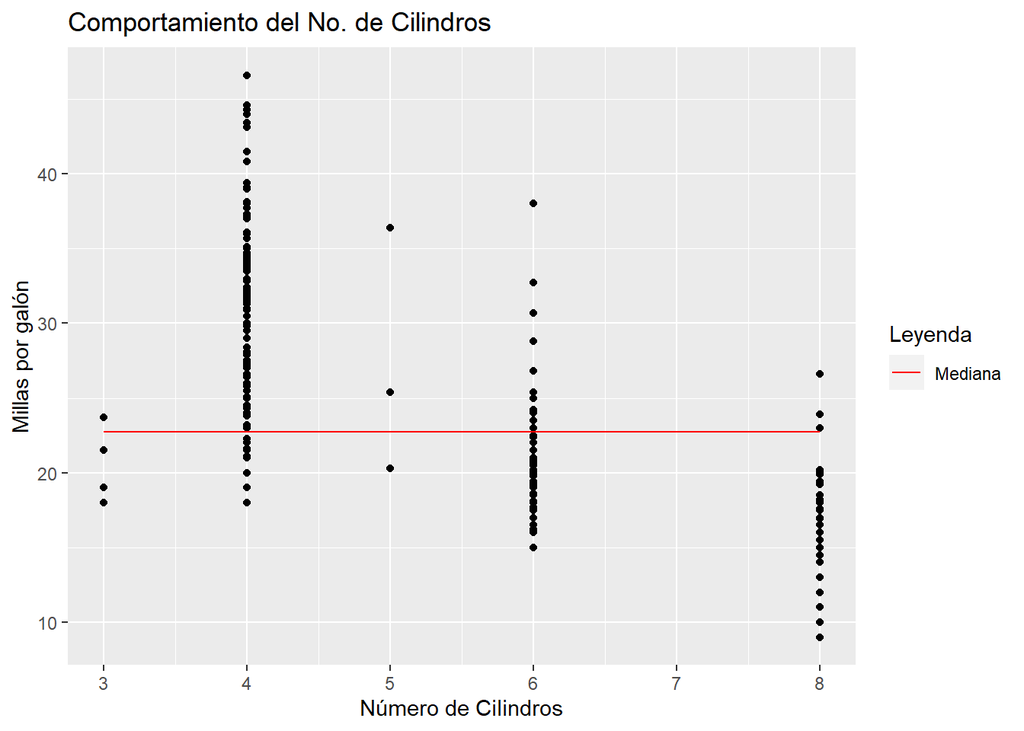

```r
# Cilindros
ggplot(data = Auto, mapping=aes(x = cylinders, y=mpg)) + geom_point() + geom_line(mapping= aes(x = cylinders,y = median(mpg), col="Mediana")) + labs(title="Comportamiento del No. de Cilindros",x = "Número de Cilindros", y = "Millas por galón", color="Leyenda") + scale_color_manual(values = c("Mediana" = "red"))
```

### Desplazamiento

En esta gráfica se nota una clara tendencia en la que los vehículos con un desplazamiento más bajo muestran el mejor rendimiento de mpg.

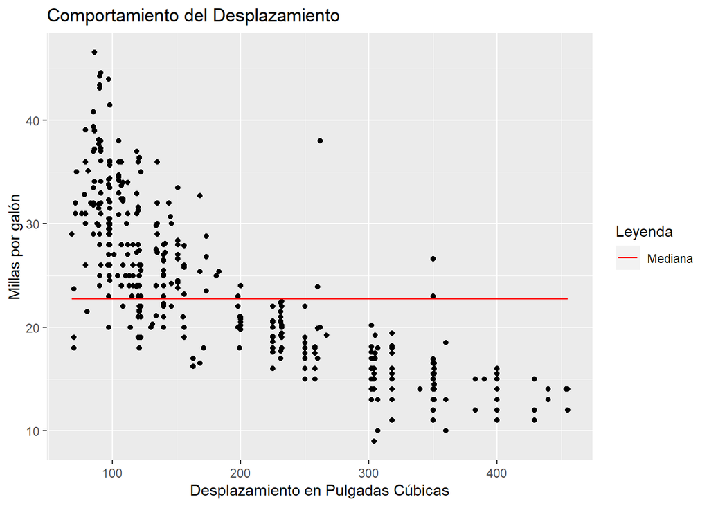

```r
# Displacement
displacement_g <- ggplot(data = Auto, mapping=aes(x = displacement, y=mpg))
displacement_g + geom_point() + geom_line(mapping= aes(x = displacement,y = median(mpg), col="Mediana")) + labs(title="Comportamiento del Desplazamiento" ,x = "Desplazamiento en Pulgadas Cúbicas", y = "Millas por galón", color="Leyenda") + scale_color_manual(values = c("Mediana" = "red"))
```

### Caballos de fuerza

Al igual que con el desplazamiento, al tener menos caballos de fuerza mejor es el rendimiento en mpg.

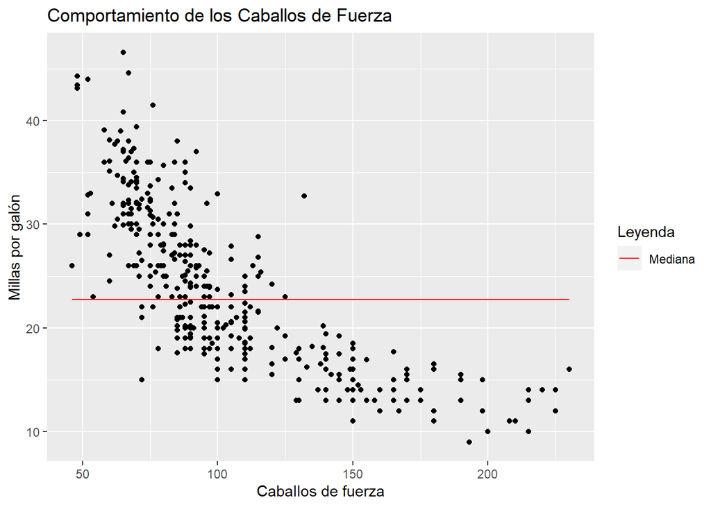

```r
horsepower_g <- ggplot(data = Auto, mapping=aes(x = horsepower, y=mpg))
horsepower_g + geom_point() + geom_line(mapping= aes(x = horsepower,y = median(mpg), col="Mediana")) + labs(title="Comportamiento de los Caballos de Fuerza",x = "Caballos de fuerza", y = "Millas por galón", color="Leyenda") + scale_color_manual(values = c("Mediana" = "red"))
```

### Masa

Al igual que el desplazamiento y los caballos de fuerza, los carros más livianos presentan un mejor rendimiento en mpg. Este comportamiento de las 3 variables podría sugerir una correlación de las mismas.

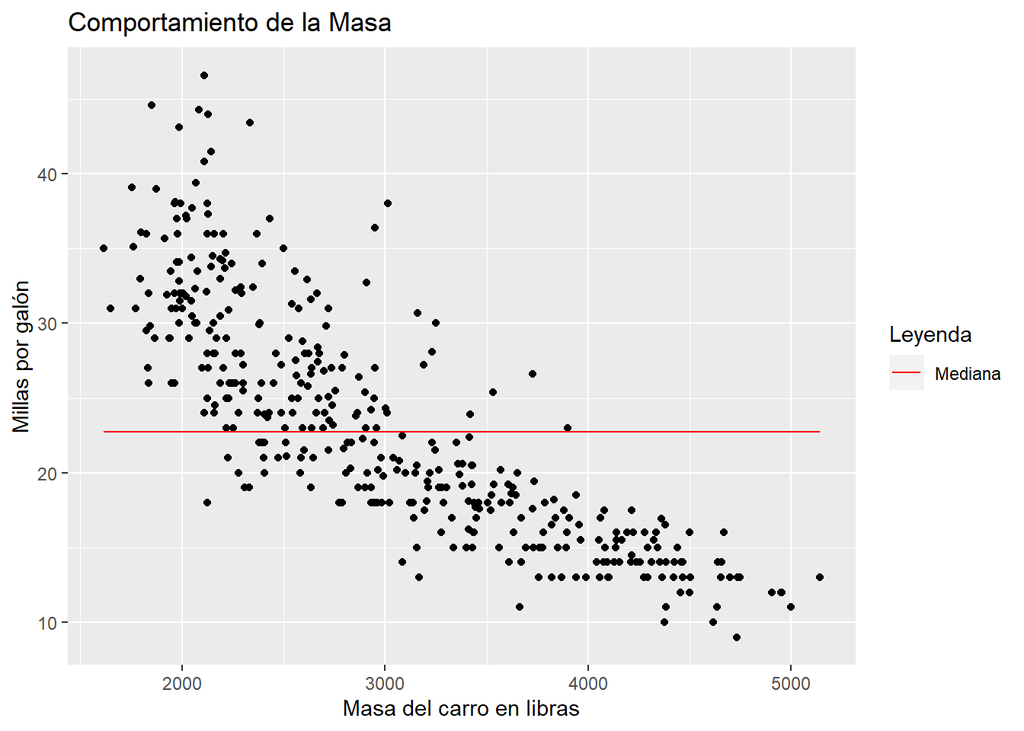

```r
weight_g <- ggplot(data = Auto, mapping=aes(x = weight, y=mpg))
weight_g + geom_point() + geom_line(mapping= aes(x = weight,y = median(mpg), col="Mediana")) + labs(title="Comportamiento de la Masa",x = "Masa del carro en libras", y = "Millas por galón", color="Leyenda") + scale_color_manual(values = c("Mediana" = "red"))
```

### Tiempo de aceleración de 0 a 60 mph

La gráfica no sugiere una relación directa entre el tiempo de aceleración, al menos para los valores entre 11 y 23 segundos, aproximadamente, sin embargo se identifica que los autos que presentan una aceleración de 10 o menos segundos generalmente presentan un mal rendimiento en mpg.

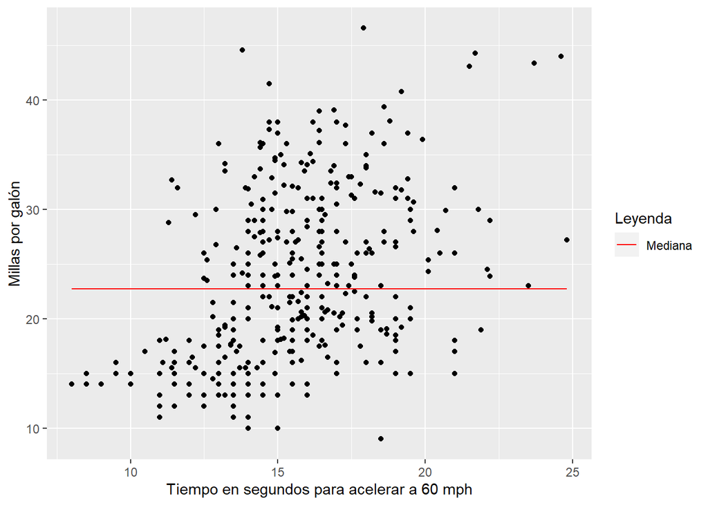

```r
accel_g <- ggplot(data = Auto, mapping=aes(x = acceleration, y=mpg))
accel_g + geom_point() + geom_line(mapping= aes(x = acceleration,y = median(mpg), col="Mediana")) + labs(titile="Comportamiento de la aceleración",x = "Tiempo en segundos para acelerar a 60 mph", y = "Millas por galón", color="Leyenda") + scale_color_manual(values = c("Mediana" = "red"))
```

### País de origen

La diferenciación por país de origen demuestra una clara diferencia en el rendimiento en mpg, donde los autos americanos presentan el peor, y los europeos y japoneses el mejor.

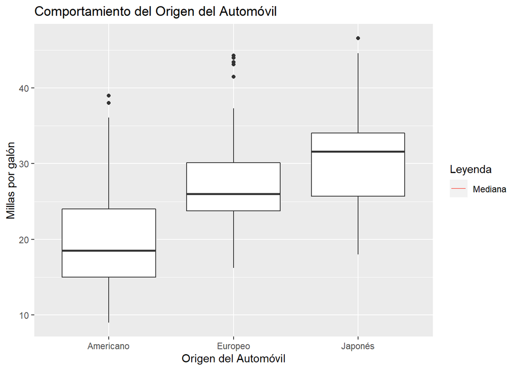

```r
# Factor de origen
Auto$forigin <- as.factor(Auto$origin)

origin_g <- ggplot(data = Auto, mapping=aes(x = forigin, y=mpg))
origin_g + geom_boxplot() + geom_line(mapping= aes(x = forigin,y = median(mpg), col="Mediana")) + labs(title="Comportamiento del Origen del Automóvil",x = "Origen del Automóvil", y = "Millas por galón", color="Leyenda") + scale_x_discrete(labels = c("1" = "Americano", "2" = "Europeo", "3" = "Japonés"))
```

### Año del modelo

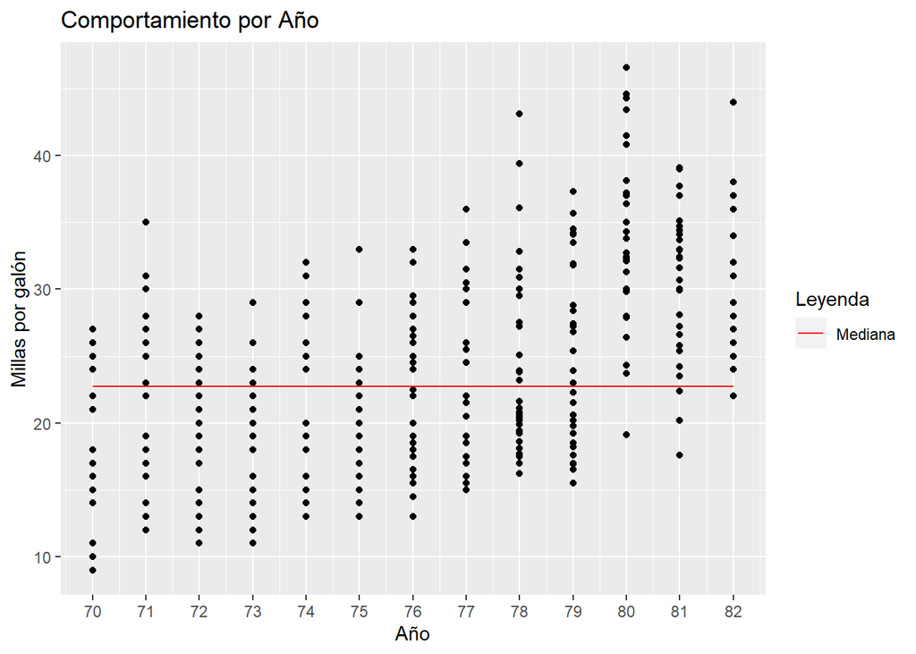

```r
year_g <- ggplot(data = Auto, mapping=aes(x = year, y=mpg))
year_g + geom_point() + geom_line(mapping= aes(x = year,y = median(mpg), col="Mediana")) + labs(title="Comportamiento por Año" ,x = "Año", y = "Millas por galón", color="Leyenda") + scale_color_manual(values = c("Mediana" = "red")) + scale_x_continuous(breaks = c(70:82))
```

### Nombre del carro

La variable de nombre del carro posee muchos niveles y una diferenciación por el mismo no sería del todo buena, ya que no se cuentan con muchos datos.

```r
length(levels(Auto$name))
```

```
## [1] 304
```

### Elección de predictores

Los predictores elegidos según el análisis serán: - Desplazamiento (displacement) - Caballos de fuerza (horsepower) - Masa del vehículo (weight) - Origen del auto (forigin)

```r
formula <- mpg01 ~ displacement + horsepower + weight + forigin
```

## Literal c), División del set de datos

Para la división del set de datos se toma una muestra aleatoria del $80\%$ para entrenamiento y el $20\%$ restante para validación.

```r
# Se encuentra el tamaño del set de datos (tomando el 80% para entrenamiento)
sample_size = floor(0.8*nrow(Auto))
set.seed(2020)

# Dividir el set de datos aleatoriamente
picked = sample(seq_len(nrow(Auto)),size = sample_size)
auto_tr =Auto[picked,]
auto_vl =Auto[-picked,]
```

## Literal d), LDA

```r
auto_lda <- lda(formula, data = auto_tr)
auto_lda
```

```
## Call:
## lda(formula, data = auto_tr)
##
## Prior probabilities of groups:
##     FALSE      TRUE
## 0.5111821 0.4888179
##
## Group means:
##       displacement horsepower   weight  forigin2  forigin3
## FALSE     273.8250  130.18125 3634.881 0.0687500 0.0500000
## TRUE      113.3889   78.35294 2312.418 0.2941176 0.3856209
##
## Coefficients of linear discriminants:
##                       LD1
## displacement -0.006321321
## horsepower    0.005530063
## weight       -0.001196922
## forigin2      0.366420649
## forigin3      0.394776068
```

```r
predicted <- predict(auto_lda, newdata=auto_vl) # Predicción
real <- auto_vl$mpg01 # Reales

c_matrix_lda <- ConfusionMatrix(predicted$class, real) # Matriz de confusión
print(sprintf("El porcentaje de aciertos para es de %f%s", Accuracy(predicted$class,real)*100, "%"))
```

```
## [1] "El porcentaje de aciertos para es de 87.341772%"
```

```r
c_matrix_lda
```

```
##        y_pred
## y_true  FALSE TRUE
##   FALSE    29    7
##   TRUE      3   40
```

## Literal e), QDA

```r
auto_qda <- qda(formula, data = auto_tr)
auto_qda
```

```
## Call:
## qda(formula, data = auto_tr)
##
## Prior probabilities of groups:
##     FALSE      TRUE
## 0.5111821 0.4888179
##
## Group means:
##       displacement horsepower   weight  forigin2  forigin3
## FALSE     273.8250  130.18125 3634.881 0.0687500 0.0500000
## TRUE      113.3889   78.35294 2312.418 0.2941176 0.3856209
```

```r
predicted <- predict(auto_qda, newdata=auto_vl) # Predicción
real <- auto_vl$mpg01 # Reales

c_matrix_qda <- ConfusionMatrix(predicted$class, real) # Matriz de confusión
print(sprintf("El porcentaje de aciertos para es de %f%s", Accuracy(predicted$class,real)*100, "%"))
```

```
## [1] "El porcentaje de aciertos para es de 89.873418%"
```

```r
c_matrix_qda
```

```
##        y_pred
## y_true  FALSE TRUE
##   FALSE    30    6
##   TRUE      2   41
```

## Literal f), Regresión logística

```r
auto_glm <- glm(formula, data= auto_tr, family="binomial")
summary(auto_glm)
```

```
##
## Call:
## glm(formula = formula, family = "binomial", data = auto_tr)
##
## Deviance Residuals:
##     Min       1Q   Median       3Q      Max
## -2.4910  -0.2100  -0.0057   0.3187   3.3680
##
## Coefficients:
##                Estimate Std. Error z value Pr(>|z|)
## (Intercept)  12.1057415  1.8999057   6.372 1.87e-10 ***
## displacement -0.0101779  0.0081147  -1.254   0.2097
## horsepower   -0.0323690  0.0158900  -2.037   0.0416 *
## weight       -0.0026066  0.0009031  -2.886   0.0039 **
## forigin2      0.2320536  0.6745525   0.344   0.7308
## forigin3      0.1129592  0.6377234   0.177   0.8594
## ---
## Signif. codes:  0 '***' 0.001 '**' 0.01 '*' 0.05 '.' 0.1 ' ' 1
##
## (Dispersion parameter for binomial family taken to be 1)
##
##     Null deviance: 433.75  on 312  degrees of freedom
## Residual deviance: 156.08  on 307  degrees of freedom
## AIC: 168.08
##
## Number of Fisher Scoring iterations: 7
```

```r
predicted <- round(predict(auto_glm, newdata=auto_vl,  type="response")) # Predicción
real <- auto_vl$mpg01 # Reales

c_matrix_glm <- ConfusionMatrix(predicted, real) # Matriz de confusión
print(sprintf("El porcentaje de aciertos para es de %f%s", Accuracy(predicted,real)*100, "%"))
```

```
## [1] "El porcentaje de aciertos para es de 86.075949%"
```

```r
c_matrix_glm
```

```
##        y_pred
## y_true   0  1
##   FALSE 29  7
##   TRUE   4 39
```

```r
# Preparación de los datos
x_tr <- cbind(auto_tr$displacement,auto_tr$horsepower, auto_tr$weight, auto_tr$forigin)
x_vl <- cbind(auto_vl$displacement,auto_vl$horsepower, auto_vl$weight, auto_vl$forigin)

y_tr <- auto_tr$mpg01
y_vl <- auto_vl$mpg01
```

La aproximación por KNN muestra unos resultados más alejados al resto en términos de efectividad, los $k$ que presentaron el mejor desempeño fueron los $k = 4$ y $k = 7$

```r
set.seed(2020)
for (k in c(1:10)) {
  predict = knn(train = x_tr, test = x_vl, cl = y_tr, k = k)
  print(sprintf("El porcentaje de aciertos para el k=%i es de %f%s", k, Accuracy(predict,y_vl)*100, "%"))
}
```

```
## [1] "El porcentaje de aciertos para el k=1 es de 84.810127%"
## [1] "El porcentaje de aciertos para el k=2 es de 82.278481%"
## [1] "El porcentaje de aciertos para el k=3 es de 82.278481%"
## [1] "El porcentaje de aciertos para el k=4 es de 86.075949%"
## [1] "El porcentaje de aciertos para el k=5 es de 83.544304%"
## [1] "El porcentaje de aciertos para el k=6 es de 84.810127%"
## [1] "El porcentaje de aciertos para el k=7 es de 86.075949%"
## [1] "El porcentaje de aciertos para el k=8 es de 84.810127%"
## [1] "El porcentaje de aciertos para el k=9 es de 83.544304%"
## [1] "El porcentaje de aciertos para el k=10 es de 82.278481%"
```

## Conclusión

El modelo que obtuvo un mejor porcentaje de aciertos fue el del QDA, seguido del LDA, por último la regresión logística y el mejor modelo de KNN obtuvieron el mismo porcentaje de aciertos.

# Punto 12

## Literal a), Funcion Power()

```r
Power <- function(){
  print(2^3)
}
Power()
```

```
## [1] 8
```

## Literal b), Funcion Power2()

```r
Power2 <- function(x,a){
  print(x^a)
}

Power2(3,8)
```

```
## [1] 6561
```

## Literal c), Uso de Power2()

```r
Power2(10,3)
```

```
## [1] 1000
```

```r
Power2(8,17)
```

```
## [1] 2.2518e+15
```

```r
Power2(131,3)
```

```
## [1] 2248091
```

## Literal d), Función Power3()

```r
Power3 <- function(x,a){
  return(x^a)
}
```

## Literal e), Gráfica de f(x)

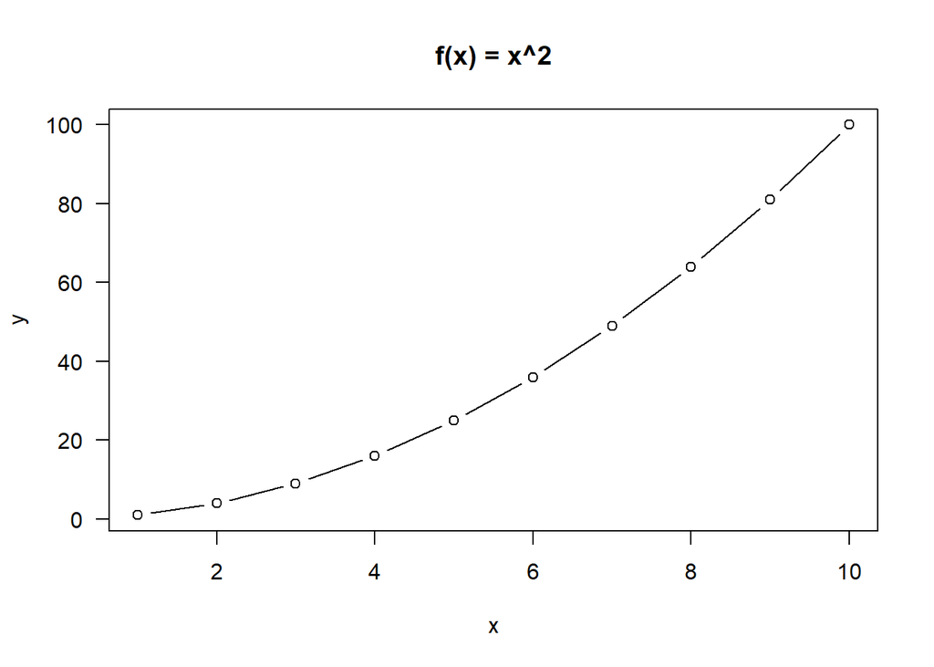

```r
plot(x = c(1:10), y = Power3(c(1:10), 2), type = "b", main = "f(x) = x^2", xlab = "x", ylab="y", las = 1)
```

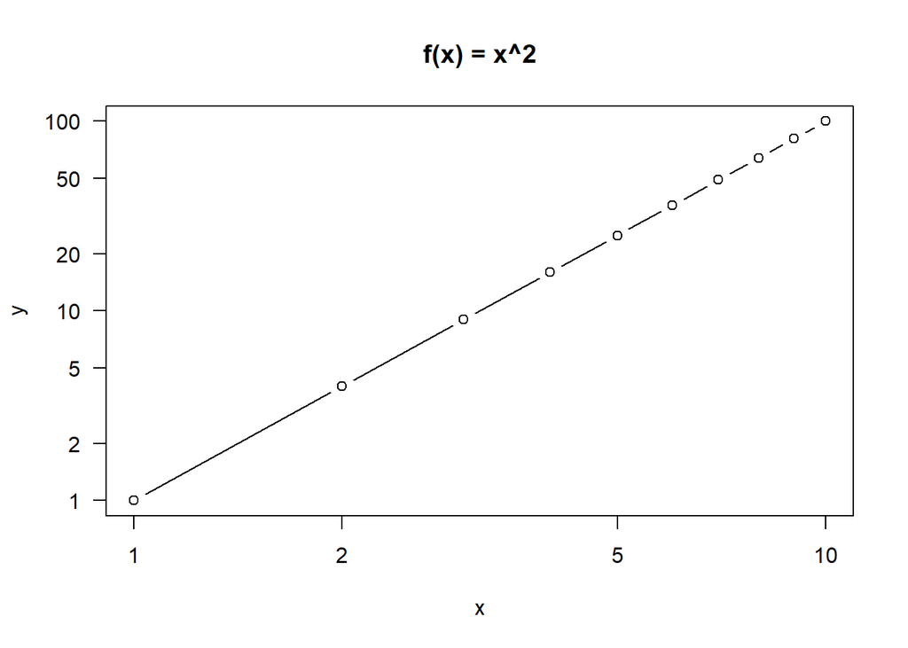

```r
plot(x = c(1:10), y = Power3(c(1:10), 2), type = "b", main = "f(x) = x^2", xlab = "x", ylab="y", las = 1, log="xy")
```

## Literal f), Función PlotPower()

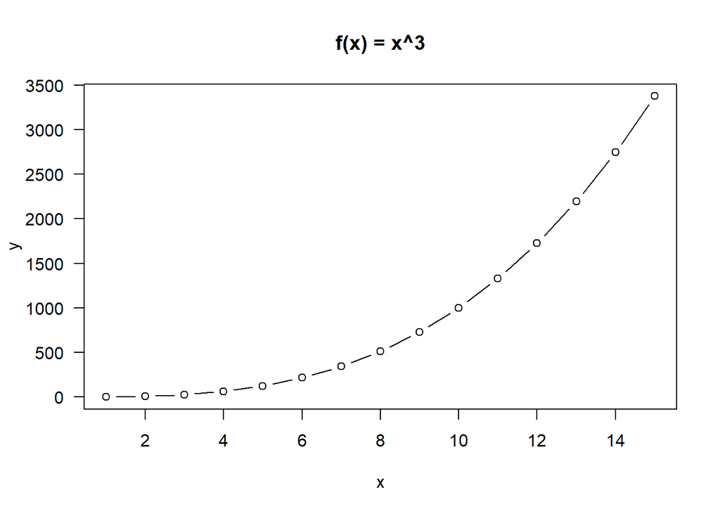

```r
PlotPower <- function(x,a){
  plot(x = x, y = Power3(x, a), type = "b", main = sprintf("f(x) = x^%i", a), xlab = "x", ylab="y", las = 1)
}

PlotPower(c(1:15), 3)
```

# Punto 13

## Introducción

En el siguiente punto el objetivo es predecir a partir de los datos si un suburbio tiene una tasa de criminalidad superior a la mediana. Se usará el set de datos Boston del paquete MASS.

## Resumen y variables

El dataset cuenta con las siguientes variables:

- crim: Tasa de criminalidad per cápita.
- zn: Proporción de terreno residencial dividido en lotes, sobre 25000 pies cuadrados.
- indus: Proporción de areas de negocios no-minoristas por suburbio.
- chas: Variable dummy donde es 1 si el suburbio limita con el río Charles y 0 si no.
- nox: Concetración de óxido de nitrógeno en partes por 10 millones.
- rm: Número promedio de habitaciones por vivienda.
- age: Proporción de viviendas ocupadas por sus dueños, construidas antes de 1940.
- dis: Media ponderada de la distancia a 5 centros de empleo de Boston.
- rad: Índice de accesibilidad a carreteras radiales.
- ptratio: Radio de pupílo-maestro por suburbio.
- black: $1000(Bk - 0.63)^2$ donde $Bk$ es la proporción de negros en el suburbio.
- lstat: Status bajo de la población (porcentaje).
- medv: Mediana de viviendas ocupadas por sus dueños en 1000$

```r
summary(Boston)
```

```
##       crim                zn             indus            chas
##  Min.   : 0.00632   Min.   :  0.00   Min.   : 0.46   Min.   :0.00000
##  1st Qu.: 0.08205   1st Qu.:  0.00   1st Qu.: 5.19   1st Qu.:0.00000
##  Median : 0.25651   Median :  0.00   Median : 9.69   Median :0.00000
##  Mean   : 3.61352   Mean   : 11.36   Mean   :11.14   Mean   :0.06917
##  3rd Qu.: 3.67708   3rd Qu.: 12.50   3rd Qu.:18.10   3rd Qu.:0.00000
##  Max.   :88.97620   Max.   :100.00   Max.   :27.74   Max.   :1.00000
##       nox               rm             age              dis
##  Min.   :0.3850   Min.   :3.561   Min.   :  2.90   Min.   : 1.130
##  1st Qu.:0.4490   1st Qu.:5.886   1st Qu.: 45.02   1st Qu.: 2.100
##  Median :0.5380   Median :6.208   Median : 77.50   Median : 3.207
##  Mean   :0.5547   Mean   :6.285   Mean   : 68.57   Mean   : 3.795
##  3rd Qu.:0.6240   3rd Qu.:6.623   3rd Qu.: 94.08   3rd Qu.: 5.188
##  Max.   :0.8710   Max.   :8.780   Max.   :100.00   Max.   :12.127
##       rad              tax           ptratio          black
##  Min.   : 1.000   Min.   :187.0   Min.   :12.60   Min.   :  0.32
##  1st Qu.: 4.000   1st Qu.:279.0   1st Qu.:17.40   1st Qu.:375.38
##  Median : 5.000   Median :330.0   Median :19.05   Median :391.44
##  Mean   : 9.549   Mean   :408.2   Mean   :18.46   Mean   :356.67
##  3rd Qu.:24.000   3rd Qu.:666.0   3rd Qu.:20.20   3rd Qu.:396.23
##  Max.   :24.000   Max.   :711.0   Max.   :22.00   Max.   :396.90
##      lstat            medv
##  Min.   : 1.73   Min.   : 5.00
##  1st Qu.: 6.95   1st Qu.:17.02
##  Median :11.36   Median :21.20
##  Mean   :12.65   Mean   :22.53
##  3rd Qu.:16.95   3rd Qu.:25.00
##  Max.   :37.97   Max.   :50.00
```

## Variable crim01

Se procede a crear una variable binaria crim01 la cuál es verdadera si la tasa de criminalidad es superior a la mediana de la tasa a lo largo del dataset, la mediana en este caso es de $0.25651$

```r
Boston$crim01 <- (Boston$crim >= median(Boston$crim))
median(Boston$crim)
```

```
## [1] 0.25651
```

FALSE indica un $0$ y TRUE indica un $1$

```r
contrasts(as.factor(Boston$crim01))
```

```
##       TRUE
## FALSE    0
## TRUE     1
```

## División del set de datos

Para la división del set de datos se toma una muestra aleatoria del $80\%$ para entrenamiento y el $20\%$ restante para validación.

```r
# Se encuentra el tamaño del set de datos (tomando el 80% para entrenamiento)
sample_size = floor(0.8*nrow(Boston))
set.seed(2020)

# Dividir el set de datos aleatoriamente
picked = sample(seq_len(nrow(Boston)),size = sample_size)
boston_tr =Boston[picked,]
boston_vl =Boston[-picked,]
```

Se realizarán diversos modelos con regresión logística, utilizando diferentes sets de predictores, los predictores se separarán según su tipo:

- Geográfico: zn, indus, chas, dis, rad
- Vivienda: rm, age, medv
- Poblacional: ptratio, black, lstat

Las variables nox y tax, se incluiran en los modelos finales ya que no se encasillan en ninguno de los grupos

De cada modelo luego se tomaran las variables que presentaron la mayor significancia y estas serán las que se usarán para cada uno de los modelos posteriores.

## Regresión logística, predictores geográficos.

Las variables con mayor significancia fueron dis,rad, zn.

```r
model_glm1 <- glm(crim01 ~ zn + indus + chas + dis + rad, data = boston_tr, family = "binomial")
summary(model_glm1)
```

```
##
## Call:
## glm(formula = crim01 ~ zn + indus + chas + dis + rad, family = "binomial",
##     data = boston_tr)
##
## Deviance Residuals:
##      Min        1Q    Median        3Q       Max
## -1.72341  -0.51300   0.00348   0.00806   2.53603
##
## Coefficients:
##             Estimate Std. Error z value Pr(>|z|)
## (Intercept) -1.02371    0.87044  -1.176   0.2396
## zn          -0.03332    0.01523  -2.188   0.0287 *
## indus        0.03820    0.02808   1.360   0.1738
## chas         0.27502    0.55134   0.499   0.6179
## dis         -0.60935    0.12642  -4.820 1.44e-06 ***
## rad          0.54076    0.11702   4.621 3.81e-06 ***
## ---
## Signif. codes:  0 '***' 0.001 '**' 0.01 '*' 0.05 '.' 0.1 ' ' 1
##
## (Dispersion parameter for binomial family taken to be 1)
##
##     Null deviance: 560.02  on 403  degrees of freedom
## Residual deviance: 255.65  on 398  degrees of freedom
## AIC: 267.65
##
## Number of Fisher Scoring iterations: 8
```

```r
predicted <- round(predict(model_glm1, newdata = boston_vl, type = "response"))
real <- boston_vl$crim01

acc <- Accuracy(predicted, real)* 100

print(sprintf("El porcentaje de aciertos fue del %f%s", acc, "%"))
```

```
## [1] "El porcentaje de aciertos fue del 81.372549%"
```

```r
ConfusionMatrix(predicted, real) # Matriz de confusión
```

```
##        y_pred
## y_true   0  1
##   FALSE 44  9
##   TRUE  10 39
```

Para las variables de vivienda, la de mayor significancia fue age.

```r
model_glm2 <- glm(crim01 ~ rm + age + medv, data= boston_tr, family = "binomial")
summary(model_glm2)
```

```
##
## Call:
## glm(formula = crim01 ~ rm + age + medv, family = "binomial",
##     data = boston_tr)
##
## Deviance Residuals:
##     Min       1Q   Median       3Q      Max
## -1.9926  -0.6806   0.5119   0.6675   2.7922
##
## Coefficients:
##              Estimate Std. Error z value Pr(>|z|)
## (Intercept) -4.807012   1.417786  -3.391 0.000698 ***
## rm           0.091781   0.252728   0.363 0.716486
## age          0.062754   0.006403   9.801  < 2e-16 ***
## medv        -0.007696   0.020459  -0.376 0.706793
## ---
## Signif. codes:  0 '***' 0.001 '**' 0.01 '*' 0.05 '.' 0.1 ' ' 1
##
## (Dispersion parameter for binomial family taken to be 1)
##
##     Null deviance: 560.02  on 403  degrees of freedom
## Residual deviance: 378.67  on 400  degrees of freedom
## AIC: 386.67
##
## Number of Fisher Scoring iterations: 5
```

```r
predicted <- round(predict(model_glm2, newdata = boston_vl, type = "response"))
real <- boston_vl$crim01

acc <- Accuracy(predicted, real)* 100

print(sprintf("El porcentaje de aciertos fue del %f%s", acc, "%"))
```

```
## [1] "El porcentaje de aciertos fue del 77.450980%"
```

```r
ConfusionMatrix(predicted, real) # Matriz de confusión
```

```
##        y_pred
## y_true   0  1
##   FALSE 34 19
##   TRUE   4 45
```

Para las variables poblacionales, las de mayor significancia fueron las variables black y lstat.

```r
model_glm3 <- glm(crim01 ~ ptratio + black + lstat, data = boston_tr, family = "binomial")
summary(model_glm3)
```

```
##
## Call:
## glm(formula = crim01 ~ ptratio + black + lstat, family = "binomial",
##     data = boston_tr)
##
## Deviance Residuals:
##     Min       1Q   Median       3Q      Max
## -3.5860  -0.8707   0.0107   0.9099   1.9611
##
## Coefficients:
##              Estimate Std. Error z value Pr(>|z|)
## (Intercept)  5.685163   2.485582   2.287 0.022181 *
## ptratio      0.034861   0.058975   0.591 0.554444
## black       -0.021138   0.006211  -3.403 0.000666 ***
## lstat        0.142127   0.023182   6.131 8.74e-10 ***
## ---
## Signif. codes:  0 '***' 0.001 '**' 0.01 '*' 0.05 '.' 0.1 ' ' 1
##
## (Dispersion parameter for binomial family taken to be 1)
##
##     Null deviance: 560.02  on 403  degrees of freedom
## Residual deviance: 430.38  on 400  degrees of freedom
## AIC: 438.38
##
## Number of Fisher Scoring iterations: 7
```

```r
predicted <- round(predict(model_glm3, newdata = boston_vl, type = "response"))
real <- boston_vl$crim01

acc <- Accuracy(predicted, real)* 100

print(sprintf("El porcentaje de aciertos fue del %f%s", acc, "%"))
```

```
## [1] "El porcentaje de aciertos fue del 74.509804%"
```

```r
ConfusionMatrix(predicted, real) # Matriz de confusión
```

```
##        y_pred
## y_true   0  1
##   FALSE 40 13
##   TRUE  13 36
```

## Predictores elegidos

Los predictores elegidos serán: - dis - rad - age - black - lstat - nox - tax

## Regresión logística

Se realiza una regresión logística con los predictores escogidos.

```r
model_glm <- glm(crim01 ~ dis + rad + age + black + lstat + nox + tax, data = boston_tr, family = "binomial")

summary(model_glm)
```

```
##
## Call:
## glm(formula = crim01 ~ dis + rad + age + black + lstat + nox +
##     tax, family = "binomial", data = boston_tr)
##
## Deviance Residuals:
##      Min        1Q    Median        3Q       Max
## -1.90854  -0.25996   0.00008   0.00414   2.61963
##
## Coefficients:
##               Estimate Std. Error z value Pr(>|z|)
## (Intercept) -19.450861   4.350661  -4.471 7.79e-06 ***
## dis           0.136719   0.168015   0.814 0.415800
## rad           0.666387   0.133441   4.994 5.92e-07 ***
## age           0.007796   0.010460   0.745 0.456059
## black        -0.007433   0.005568  -1.335 0.181947
## lstat         0.004825   0.039166   0.123 0.901955
## nox          39.128187   6.635208   5.897 3.70e-09 ***
## tax          -0.009910   0.002701  -3.669 0.000243 ***
## ---
## Signif. codes:  0 '***' 0.001 '**' 0.01 '*' 0.05 '.' 0.1 ' ' 1
##
## (Dispersion parameter for binomial family taken to be 1)
##
##     Null deviance: 560.02  on 403  degrees of freedom
## Residual deviance: 190.33  on 396  degrees of freedom
## AIC: 206.33
##
## Number of Fisher Scoring iterations: 8
```

El porcentaje de aciertos si aumenta respecto a los modelos anteriores, pero se sospecha que es por la inclusión de las variables nox y tax. Se realizará un modelo con todas las variables para ver el contraste.

```r
predicted <- round(predict(model_glm, newdata = boston_vl, type = "response"))
real <- boston_vl$crim01

acc <- Accuracy(predicted, real) * 100

print(sprintf("El porcentaje de aciertos fue del %f%s", acc, "%"))
```

```
## [1] "El porcentaje de aciertos fue del 83.333333%"
```

```r
ConfusionMatrix(predicted, real) # Matriz de confusión
```

```
##        y_pred
## y_true   0  1
##   FALSE 44  9
##   TRUE   8 41
```

A continuación se realiza una regresión logística con todas las variables.

```r
model_glm <- glm(crim01 ~ zn + indus + chas + nox + rm + age + dis + rad + tax + ptratio + black + lstat + medv, data = boston_tr, family = "binomial")

summary(model_glm)
```

```
##
## Call:
## glm(formula = crim01 ~ zn + indus + chas + nox + rm + age + dis +
##     rad + tax + ptratio + black + lstat + medv, family = "binomial",
##     data = boston_tr)
##
## Deviance Residuals:
##     Min       1Q   Median       3Q      Max
## -1.8878  -0.1486   0.0000   0.0022   3.2456
##
## Coefficients:
##               Estimate Std. Error z value Pr(>|z|)
## (Intercept) -31.498628   6.802443  -4.630 3.65e-06 ***
## zn           -0.071444   0.034115  -2.094  0.03624 *
## indus        -0.004212   0.053722  -0.078  0.93750
## chas          0.478901   0.807239   0.593  0.55301
## nox          44.803595   8.223846   5.448 5.09e-08 ***
## rm           -0.486381   0.778876  -0.624  0.53232
## age           0.016017   0.012749   1.256  0.20900
## dis           0.569745   0.228907   2.489  0.01281 *
## rad           0.725147   0.172624   4.201 2.66e-05 ***
## tax          -0.008332   0.003035  -2.745  0.00605 **
## ptratio       0.271237   0.134621   2.015  0.04392 *
## black        -0.008655   0.005567  -1.555  0.12001
## lstat         0.068000   0.057365   1.185  0.23586
## medv          0.174126   0.073687   2.363  0.01813 *
## ---
## Signif. codes:  0 '***' 0.001 '**' 0.01 '*' 0.05 '.' 0.1 ' ' 1
##
## (Dispersion parameter for binomial family taken to be 1)
##
##     Null deviance: 560.02  on 403  degrees of freedom
## Residual deviance: 171.87  on 390  degrees of freedom
## AIC: 199.87
##
## Number of Fisher Scoring iterations: 9
```

El porcentaje de aciertos hasta ahora es el mejor de todos los modelos, sin embargo se realizará un modelo con las variables que parecen tener significancia del modelo.

```r
predicted <- round(predict(model_glm, newdata = boston_vl, type = "response"))
real <- boston_vl$crim01

acc <- Accuracy(predicted, real)* 100

print(sprintf("El porcentaje de aciertos fue del %f%s", acc, "%"))
```

```
## [1] "El porcentaje de aciertos fue del 87.254902%"
```

```r
ConfusionMatrix(predicted, real) # Matriz de confusión
```

```
##        y_pred
## y_true   0  1
##   FALSE 45  8
##   TRUE   5 44
```

```r
model_glm <- glm(crim01 ~ zn + nox + dis + rad + tax + ptratio + medv, data = boston_tr, family = "binomial")
summary(model_glm)
```

```
##
## Call:
## glm(formula = crim01 ~ zn + nox + dis + rad + tax + ptratio +
##     medv, family = "binomial", data = boston_tr)
##
## Deviance Residuals:
##      Min        1Q    Median        3Q       Max
## -2.04249  -0.20026   0.00006   0.00343   3.06622
##
## Coefficients:
##               Estimate Std. Error z value Pr(>|z|)
## (Intercept) -30.508465   5.637643  -5.412 6.25e-08 ***
## zn           -0.062811   0.030345  -2.070  0.03846 *
## nox          43.648472   6.933642   6.295 3.07e-10 ***
## dis           0.363455   0.200774   1.810  0.07025 .
## rad           0.682218   0.149559   4.562 5.08e-06 ***
## tax          -0.007849   0.002667  -2.943  0.00325 **
## ptratio       0.176106   0.113791   1.548  0.12171
## medv          0.077650   0.033965   2.286  0.02224 *
## ---
## Signif. codes:  0 '***' 0.001 '**' 0.01 '*' 0.05 '.' 0.1 ' ' 1
##
## (Dispersion parameter for binomial family taken to be 1)
##
##     Null deviance: 560.02  on 403  degrees of freedom
## Residual deviance: 181.24  on 396  degrees of freedom
## AIC: 197.24
##
## Number of Fisher Scoring iterations: 9
```

El porcentaje de aciertos no mejora respecto al modelo con todas las variables, entonces se usarán todas las variables como predictores.

```r
predicted <- round(predict(model_glm, newdata = boston_vl, type = "response"))
real <- boston_vl$crim01

acc <- Accuracy(predicted, real)* 100

print(sprintf("El porcentaje de aciertos fue del %f%s", acc, "%"))
```

```
## [1] "El porcentaje de aciertos fue del 85.294118%"
```

```r
boston_fml <- crim01 ~ zn + indus + chas + nox + rm + age + dis + rad + tax + ptratio + black + lstat + medv
```

```r
boston_qda <- qda(boston_fml, data = boston_tr)
boston_qda
```

```
## Call:
## qda(boston_fml, data = boston_tr)
##
## Prior probabilities of groups:
##     FALSE      TRUE
## 0.4950495 0.5049505
##
## Group means:
##              zn    indus       chas       nox       rm      age      dis
## FALSE 21.770000  6.85325 0.06000000 0.4707995 6.396955 50.81350 5.135899
## TRUE   1.490196 15.20843 0.09313725 0.6369216 6.210858 85.17059 2.496911
##           rad      tax  ptratio    black    lstat     medv
## FALSE  4.1450 306.5650 17.90500 388.4158  9.24765 24.94350
## TRUE  14.7402 506.2353 18.82108 331.0183 15.59593 20.38284
```

```r
predicted <- predict(boston_qda, newdata=boston_vl) # Predicción
real <- boston_vl$crim01 # Reales

c_matrix_qda <- ConfusionMatrix(predicted$class, real) # Matriz de confusión
print(sprintf("El porcentaje de aciertos para es de %f%s", Accuracy(predicted$class,real)*100, "%"))
```

```
## [1] "El porcentaje de aciertos para es de 89.215686%"
```

```r
c_matrix_qda
```

```
##        y_pred
## y_true  FALSE TRUE
##   FALSE    51    2
##   TRUE      9   40
```

```r
boston_lda <- lda(boston_fml, data = boston_tr)
boston_lda
```

```
## Call:
## lda(boston_fml, data = boston_tr)
##
## Prior probabilities of groups:
##     FALSE      TRUE
## 0.4950495 0.5049505
##
## Group means:
##              zn    indus       chas       nox       rm      age      dis
## FALSE 21.770000  6.85325 0.06000000 0.4707995 6.396955 50.81350 5.135899
## TRUE   1.490196 15.20843 0.09313725 0.6369216 6.210858 85.17059 2.496911
##           rad      tax  ptratio    black    lstat     medv
## FALSE  4.1450 306.5650 17.90500 388.4158  9.24765 24.94350
## TRUE  14.7402 506.2353 18.82108 331.0183 15.59593 20.38284
##
## Coefficients of linear discriminants:
##                   LD1
## zn      -0.0059989846
## indus    0.0354609587
## chas    -0.1896438257
## nox      7.8437023277
## rm       0.0522461281
## age      0.0108681241
## dis      0.0339569971
## rad      0.0965538073
## tax     -0.0022916846
## ptratio -0.0024566866
## black   -0.0006313999
## lstat    0.0172151193
## medv     0.0418635460
```

```r
predicted <- predict(boston_lda, newdata=boston_vl) # Predicción
real <- boston_vl$crim01 # Reales

c_matrix_lda <- ConfusionMatrix(predicted$class, real) # Matriz de confusión
print(sprintf("El porcentaje de aciertos para es de %f%s", Accuracy(predicted$class,real)*100, "%"))
```

```
## [1] "El porcentaje de aciertos para es de 83.333333%"
```

```r
c_matrix_lda
```

```
##        y_pred
## y_true  FALSE TRUE
##   FALSE    48    5
##   TRUE     12   37
```

```r
# Preparación de los datos
x_tr <- cbind(boston_tr)
x_vl <- cbind(boston_vl)

y_tr <- boston_tr$crim01
y_vl <- boston_vl$crim01
```

## Aproximación por KNN

El k que genera el mejor porcentaje de aciertos es $k=4$.

```r
for (k in c(1:10)) {
  set.seed(2020)
  predict = knn(train = x_tr, test = x_vl, cl = y_tr, k = k)
  print(sprintf("El porcentaje de aciertos para el k=%i es de %f%s", k, Accuracy(predict,y_vl)*100, "%"))
}
```

```
## [1] "El porcentaje de aciertos para el k=1 es de 93.137255%"
## [1] "El porcentaje de aciertos para el k=2 es de 93.137255%"
## [1] "El porcentaje de aciertos para el k=3 es de 95.098039%"
## [1] "El porcentaje de aciertos para el k=4 es de 96.078431%"
## [1] "El porcentaje de aciertos para el k=5 es de 95.098039%"
## [1] "El porcentaje de aciertos para el k=6 es de 94.117647%"
## [1] "El porcentaje de aciertos para el k=7 es de 94.117647%"
## [1] "El porcentaje de aciertos para el k=8 es de 94.117647%"
## [1] "El porcentaje de aciertos para el k=9 es de 93.137255%"
## [1] "El porcentaje de aciertos para el k=10 es de 94.117647%"
```

Los resultados del KNN con $k=4$.

```r
set.seed(2020)
predict = knn(train = x_tr, test = x_vl, cl = y_tr, k = 4)
print(sprintf("El porcentaje de aciertos para el k=%i es de %f%s", 4, Accuracy(predict,y_vl)*100,"%"))
```

```
## [1] "El porcentaje de aciertos para el k=4 es de 96.078431%"
```

```r
table(predict, y_vl)
```

```
##        y_vl
## predict FALSE TRUE
##   FALSE    51    2
##   TRUE      2   47
```

## Conclusión

El modelo que presentó la mejor métrica de porcentaje de aciertos fue KNN con $k=4$, con un $96\%$. Las otras aproximaciones como el LDA, GLM, QDA presentan un rendimiento más bajo, yendo desde $83\%$ hasta $89\%$. Realizando el análisis de predictores con la regresión logística, se definió que todas las variables aportaban un poco de significancia a la predicción, presentando el mejor rendimiento al usar todas las variables en el modelo.